# Estimating trends

Anthony Davidson

2019-10-11

# 1 Overview

Chapter 2.

This report investigates the estimation of the rates of change between seasons. The data is in a similar structure as historically used for estimation of numerical and functional responses.

# 2 Introduction

*Generally look at thesis drafts here.*

These files are the supporting documetation to the data-wrangling code in the Beech forest manuscript here.

But there is also many other supporting resources and less formal tutorials on my [website](https://www.ssnhub.com).

# 3 Method

This report breaks down the parameter estimates from the bayesian hierarical model in the context of our predictions and the data we collected.

# 4 Data

First the data for each parameter needs to be extracted and plotted. It can be hard to extract the information needed from a Bayesian output so I have left this for another vignette. For now I have just extracted the needed inforamtion for this paper.

*I Have used the following two datasets generated from the `Davidson_2019_Data_warngling.RMD` file*

|  | N | se.N | lcl.N | ucl.N | var | grid | trip | grid.n | trip.no | valley | control | Valley | year | month | cum.seed | seed.account.N | log.seed | valley.rep | grid.rats | Conditions | grouping.1 | grouping.2 | grouping.3 | grouping.4 | true.date | treat.six | Rats | Control | Date | … |
| --- | --- | --- | --- | --- | --- | --- | --- | --- | --- | --- | --- | --- | --- | --- | --- | --- | --- | --- | --- | --- | --- | --- | --- | --- | --- | --- | --- | --- | --- | --- |
| 1 | 85.18592 | 17.2583357469548 | 53 | 114 | N[1,1] | egl M1 | 1 | 1 | 1 | egl | control | Eglinton | 1999 | May | 590.781767252356 | 6.93520440059056 | 2.77142708362048 | egl | M1 | rats.removed | treat.highN | treat.highN | treat.highN | treat.highN | 1999-05-01 | egl control rats.removed | Reduced | Yes | 1999-05-01 | … |
| 2 | 141.346453333333 | 24.81369611494 | 103 | 200 | N[2,1] | egl M1 | 2 | 1 | 2 | egl | control | Eglinton | 1999 | Aug | 621.339444868857 | 4.3958615884303 | 2.79332892506831 | egl | M1 | rats.removed | treat.highN | treat.highN | treat.highN | treat.highN | 1999-08-01 | egl control rats.removed | Reduced | Yes | 1999-08-01 | … |
| 3 | 125.542906666667 | 15.717428731668 | 100 | 162 | N[3,1] | egl M1 | 3 | 1 | 3 | egl | control | Eglinton | 1999 | Nov | 631.52533740769 | 5.03035459489938 | 2.8003907795558 | egl | M1 | rats.removed | treat.highN | treat.highN | treat.highN | treat.highN | 1999-11-01 | egl control rats.removed | Reduced | Yes | 1999-11-01 | … |
| 4 | 23.7692733333333 | 1.66135796043198 | 22 | 28 | N[4,1] | egl M1 | 4 | 1 | 4 | egl | control | Eglinton | 2000 | Feb | 20.3717850776674 | 0.85706385685332 | 1.30902908572153 | egl | M1 | rats.removed | treat.lowN | treat.highN | treat.highN | treat.highN | 2000-02-01 | egl control rats.removed | Reduced | Yes | 2000-02-01 | … |
| 5 | 89.5302533333333 | 18.5405013345672 | 57 | 125 | N[5,1] | egl M1 | 5 | 1 | 5 | egl | control | Eglinton | 2000 | May | 1324.16603004838 | 14.7901517168541 | 3.12194244236438 | egl | M1 | rats.removed | treat.highN | treat.highN | treat.highN | treat.highN | 2000-05-01 | egl control rats.removed | Reduced | Yes | 2000-05-01 | … |
| 6 | 132.574113333333 | 24.5620600896137 | 88 | 179 | N[6,1] | egl M1 | 6 | 1 | 6 | egl | control | Eglinton | 2000 | Aug | 1701.04405398523 | 12.8308914252986 | 3.23071556120513 | egl | M1 | rats.removed | treat.highN | treat.highN | treat.highN | treat.highN | 2000-08-01 | egl control rats.removed | Reduced | Yes | 2000-08-01 | … |
| 7 | 122.07594 | 18.1190610992651 | 93 | 164 | N[7,1] | egl M1 | 7 | 1 | 7 | egl | control | Eglinton | 2000 | Nov | 1716.32289279348 | 14.0594689894952 | 3.2345989952649 | egl | M1 | rats.removed | treat.highN | treat.highN | treat.highN | treat.highN | 2000-11-01 | egl control rats.removed | Reduced | Yes | 2000-11-01 | … |
| 8 | 31.7279866666667 | 4.55005642088591 | 25 | 43 | N[8,1] | egl M1 | 8 | 1 | 8 | egl | control | Eglinton | 2001 | Feb | 0 | 0 | 0 | egl | M1 | rats.removed | treat.lowN | treat.highN | treat.lowN | treat.lowN | 2001-02-01 | egl control rats.removed | Reduced | Yes | 2001-02-01 | … |
| 9 | 17.7766 | 3.49721803393686 | 13 | 26 | N[9,1] | egl M1 | 9 | 1 | 9 | egl | control | Eglinton | 2001 | May | 0 | 0 | 0 | egl | M1 | rats.removed | treat.lowN | treat.highN | treat.lowN | treat.lowN | 2001-05-01 | egl control rats.removed | Reduced | Yes | 2001-05-01 | … |
| 10 | 1.72549333333333 | 1.48485491611685 | 0 | 5 | N[10,1] | egl M1 | 10 | 1 | 10 | egl | control | Eglinton | 2001 | Aug | 0 | 0 | 0 | egl | M1 | rats.removed | treat.lowN | treat.lowN | treat.lowN | treat.lowN | 2001-08-01 | egl control rats.removed | Reduced | Yes | 2001-08-01 | … |

[output cut: 134 more lines]

## 4.1 Reduce dataset

```
# A tibble: 144 x 9
        N lcl.N ucl.N var     grid   Control Valley    trip grid.n
    <dbl> <dbl> <dbl> <chr>   <chr>  <chr>   <fct>    <dbl>  <dbl>
 1  85.2     53   114 N[1,1]  egl M1 Yes     Eglinton     1      1
 2 141.     103   200 N[2,1]  egl M1 Yes     Eglinton     2      1
 3 126.     100   162 N[3,1]  egl M1 Yes     Eglinton     3      1
 4  23.8     22    28 N[4,1]  egl M1 Yes     Eglinton     4      1
 5  89.5     57   125 N[5,1]  egl M1 Yes     Eglinton     5      1
 6 133.      88   179 N[6,1]  egl M1 Yes     Eglinton     6      1
 7 122.      93   164 N[7,1]  egl M1 Yes     Eglinton     7      1
 8  31.7     25    43 N[8,1]  egl M1 Yes     Eglinton     8      1
 9  17.8     13    26 N[9,1]  egl M1 Yes     Eglinton     9      1
10   1.73     0     5 N[10,1] egl M1 Yes     Eglinton    10      1
# ... with 134 more rows
```

### 4.1.1 Wrangling

```
# A tibble: 144 x 34
        N  se.N lcl.N ucl.N var   grid   trip grid.n trip.no valley control
    <dbl> <dbl> <dbl> <dbl> <chr> <chr> <dbl>  <dbl>   <dbl> <chr>  <chr>
 1  85.2  17.3     53   114 N[1,~ egl ~     1      1       1 egl    control
 2 141.   24.8    103   200 N[2,~ egl ~     2      1       2 egl    control
 3 126.   15.7    100   162 N[3,~ egl ~     3      1       3 egl    control
 4  23.8   1.66    22    28 N[4,~ egl ~     4      1       4 egl    control
 5  89.5  18.5     57   125 N[5,~ egl ~     5      1       5 egl    control
 6 133.   24.6     88   179 N[6,~ egl ~     6      1       6 egl    control
 7 122.   18.1     93   164 N[7,~ egl ~     7      1       7 egl    control
 8  31.7   4.55    25    43 N[8,~ egl ~     8      1       8 egl    control
 9  17.8   3.50    13    26 N[9,~ egl ~     9      1       9 egl    control
10   1.73  1.48     0     5 N[10~ egl ~    10      1      10 egl    control
# ... with 134 more rows, and 23 more variables: Valley <fct>, year <dbl>,
#   month <chr>, cum.seed <dbl>, seed.account.N <dbl>, log.seed <dbl>,
#   valley.rep <chr>, grid.rats <chr>, Conditions <chr>, grouping.1 <chr>,
#   grouping.2 <chr>, grouping.3 <chr>, grouping.4 <chr>,
#   true.date <date>, treat.six <chr>, Rats <chr>, Control <chr>,
#   Date <date>, Treatments <chr>, Prediction <chr>, n <dbl>,
#   rat.mna <dbl>, lag.rat.mna <dbl>
```

### 4.1.2 Extracting rates from model outputs

```
# A tibble: 144 x 38
        N  se.N lcl.N ucl.N var   grid   trip grid.n trip.no valley control
    <dbl> <dbl> <dbl> <dbl> <chr> <chr> <dbl>  <dbl>   <dbl> <chr>  <chr>
 1  85.2  17.3     53   114 N[1,~ egl ~     1      1       1 egl    control
 2 141.   24.8    103   200 N[2,~ egl ~     2      1       2 egl    control
 3 126.   15.7    100   162 N[3,~ egl ~     3      1       3 egl    control
 4  23.8   1.66    22    28 N[4,~ egl ~     4      1       4 egl    control
 5  89.5  18.5     57   125 N[5,~ egl ~     5      1       5 egl    control
 6 133.   24.6     88   179 N[6,~ egl ~     6      1       6 egl    control
 7 122.   18.1     93   164 N[7,~ egl ~     7      1       7 egl    control
 8  31.7   4.55    25    43 N[8,~ egl ~     8      1       8 egl    control
 9  17.8   3.50    13    26 N[9,~ egl ~     9      1       9 egl    control
10   1.73  1.48     0     5 N[10~ egl ~    10      1      10 egl    control
# ... with 134 more rows, and 27 more variables: Valley <fct>, year <dbl>,
#   month <chr>, cum.seed <dbl>, seed.account.N <dbl>, log.seed <dbl>,
#   valley.rep <chr>, grid.rats <chr>, Conditions <chr>, grouping.1 <chr>,
#   grouping.2 <chr>, grouping.3 <chr>, grouping.4 <chr>,
#   true.date <date>, treat.six <chr>, Rats <chr>, Control <chr>,
#   Date <date>, Treatments <chr>, Prediction <chr>, n <dbl>,
#   rat.mna <dbl>, lag.rat.mna <dbl>, mean.r <dbl>, se.r <dbl>,
#   lcl.r <dbl>, ucl.r <dbl>
```

### 4.1.3 Parameter dataset

```
# A tibble: 12 x 11
   Valley Control month dat.seed.mean dat.rat.mean dat.mice.min
   <fct>  <chr>   <chr>         <dbl>        <dbl>        <dbl>
 1 Eglin~ Yes     Aug           2.01          1.75        1.43
 2 Eglin~ Yes     Feb           0.473         5.5         0.967
 3 Eglin~ Yes     May           1.57          2.88        0.598
 4 Eglin~ Yes     Nov           2.01          2           0.560
 5 Holly~ No      Aug           1.33          5.38        1.20
 6 Holly~ No      Feb           0.707         4.62        5.83
 7 Holly~ No      May           1.12          3.77        0.429
 8 Holly~ No      Nov           1.45          4.5         0.481
 9 Holly~ Yes     Aug           1.90          3.67        2.32
10 Holly~ Yes     Feb           0.338         2.4         0.528
11 Holly~ Yes     May           1.62          5           1.51
12 Holly~ Yes     Nov           2.05          3.33        0.414
# ... with 5 more variables: dat.seed.min <dbl>, dat.rat.min <dbl>,
#   dat.mice.max <dbl>, dat.seed.max <dbl>, dat.rat.max <dbl>
```

### 4.1.4 Reconstructing parameter dataset

```
Observations: 48
Variables: 6
$ mean.b   <dbl> 0.46081204, -0.25878996, -0.16741136, -0.51423246, -0...
$ Control  <chr> "control", "no control", "control", "control", "no co...
$ Valley   <chr> "egl", "hol", "hol", "egl", "hol", "hol", "egl", "hol...
$ month    <chr> "Feb", "Feb", "Feb", "May", "May", "May", "Aug", "Aug...
$ para     <fct> Intercept, Intercept, Intercept, Intercept, Intercept...
$ Estimate <dbl> 0.46081204, -0.25878996, -0.16741136, -0.51423246, -0...
```

## 4.2 Output datasets

- Parameter estimates: *n =* **48**
- Rate of change: *n =* **136**
- Abundance *n =* **144**

# 5 Applications

Overall there are many combinations of plots that can be produced from a bayesian hierarichal model.

```
Observations: 48
Variables: 6
$ mean.b   <dbl> 0.46081204, -0.25878996, -0.16741136, -0.51423246, -0...
$ Control  <chr> "Yes", "No", "Yes", "Yes", "No", "Yes", "Yes", "No", ...
$ Valley   <chr> "Eglinton", "Hollyford", "Hollyford", "Eglinton", "Ho...
$ month    <chr> "Feb", "Feb", "Feb", "May", "May", "May", "Aug", "Aug...
$ para     <chr> "Intercept", "Intercept", "Intercept", "Intercept", "...
$ Estimate <dbl> 0.46081204, -0.25878996, -0.16741136, -0.51423246, -0...
```

## 5.1 Seed by month

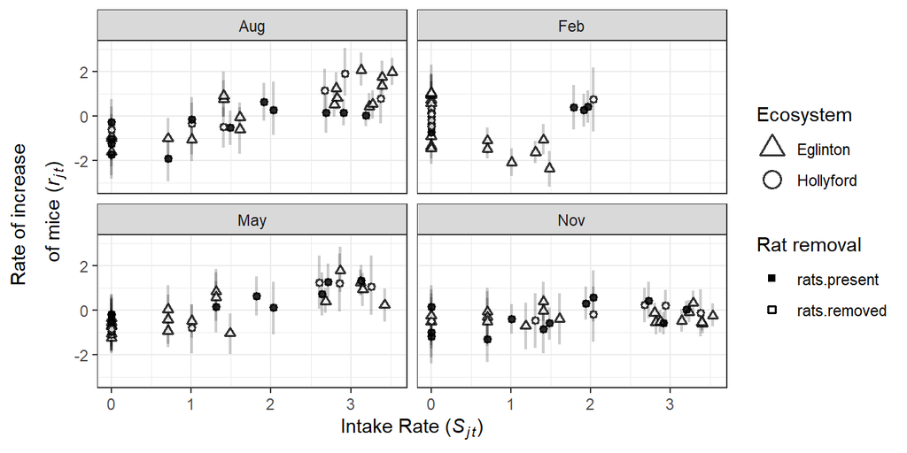

### 5.1.1 February

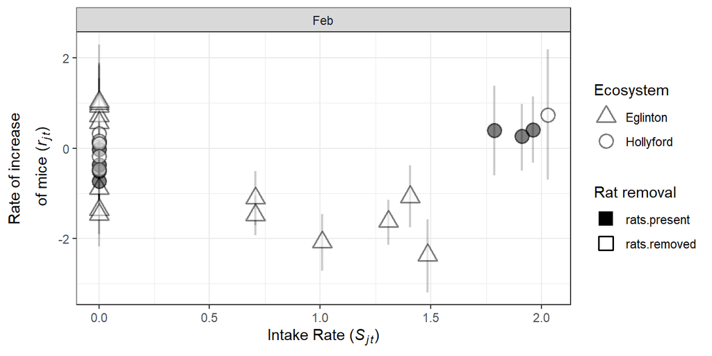

### 5.1.2 May

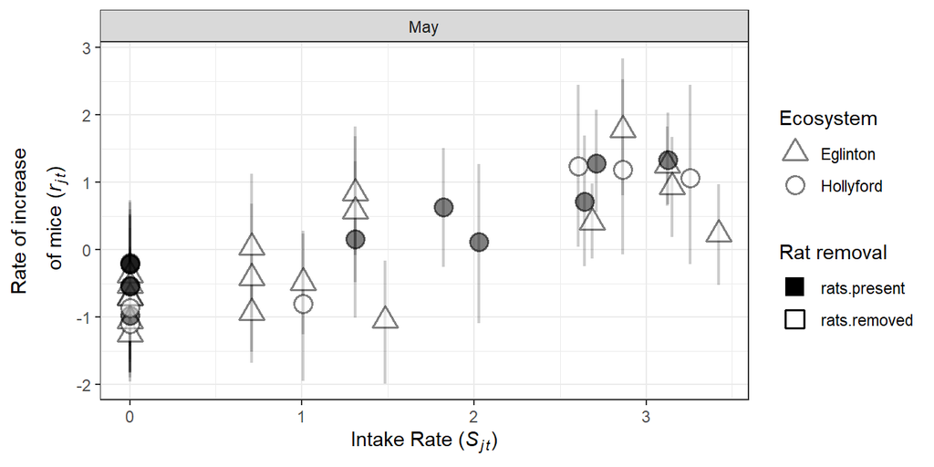

```r
seed.trend.may <- out.full.136 %>%
                select(mean.r, lcl.r, ucl.r, log.seed, Valley, control, Conditions, month) %>%
                  mutate(N = as.numeric(mean.r)) %>%
  filter(month == "May")

  ggplot(seed.trend.may, aes(y = mean.r, x = log.seed)) +
geom_errorbar(aes(ymin = lcl.r, ymax = ucl.r), lwd = 0.75, alpha = 0.2, position=position_dodge(width=30), width = 0) +
  geom_point(aes(colour = Conditions ,shape = Valley, fill = control),
             stroke = 1.05, size = 4, alpha = 0.5) +
  facet_wrap(~month) +
 scale_color_manual(name = "Rat removal",
                     values = c("black", "black")) +

  scale_shape_manual(name = "Ecosystem",
                     values = c(24, 21)) +

  scale_fill_manual(name = "Stoat control",
                    values = c("white", "black")) +

xlab(expression(paste("Intake"," ", "Rate"," ","(",italic(S[jt]),")" ))) +
# xlab(expression(paste("Mouse"," ", "Density"," ","(",italic(N[jt]),")" ))) +
# xlab(expression(atop(paste("Minimum"," ", "number"," "),paste("of", " ", "rats"," ","(",italic(R[jt]),")"))) )+
# xlab(expression(atop(paste("Minimum"," ", "number"," "),paste("of", " ", "rats"," ","(",italic(R[jt]),")"))) )+

ylab(expression(atop(paste("Rate"," ", "of"," ",
                           "increase"),paste(" ", "of"," ",
                                             "mice"," ","(",italic(r[jt]),")"))) ) +

  guides(fill = "none",
         col = guide_legend(override.aes = list(
           shape = c(15,0), alpha = 1
         )),
         shape = guide_legend(override.aes = list(
           shape = c(24, 21), size = 4
         ))) +

  #theme
theme_bw()
```

### 5.1.3 August

*Autumn and Winter trends* - Rate of increase between Autumn and Winter - May and August rate of change - May mice abundace, seed and rat data

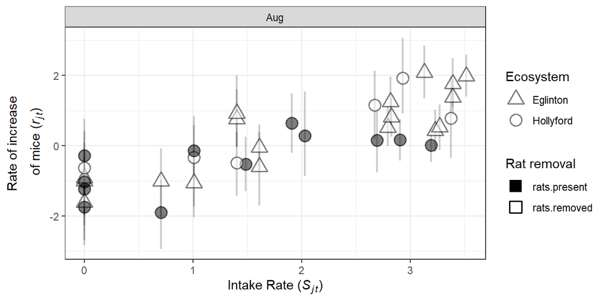

### 5.1.4 November

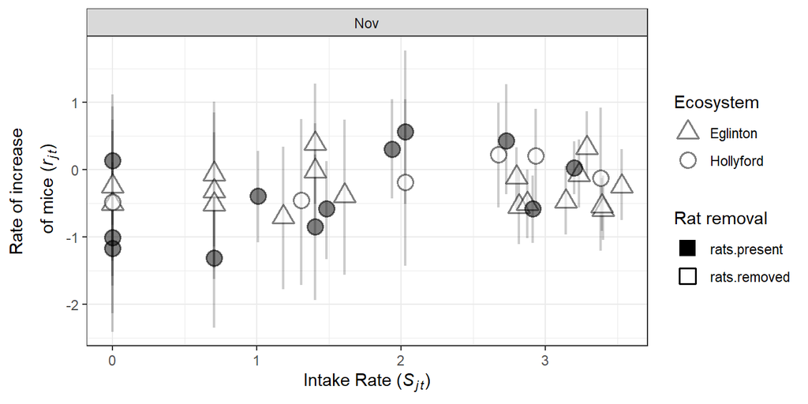

## 5.2 Estimating lines

This is where it gets really tricky. I have done this in a way that works. I am sure there are better ways to code this but that is for a later date.

My steps are:

1. `out.final1` and filter out only month of interest
2. Find max values
- background points
2. `spread` data across the different parameter estimates
3. reduce the `out.full.136` to only `feb`
4. Merge with parameter dataset (steps1-2)
5. Plot away using `ggplot2`

### 5.2.1 Seed

This is ok becuase the average estimates of line will all use the same average to estimate the trend line for each parameter and variable.

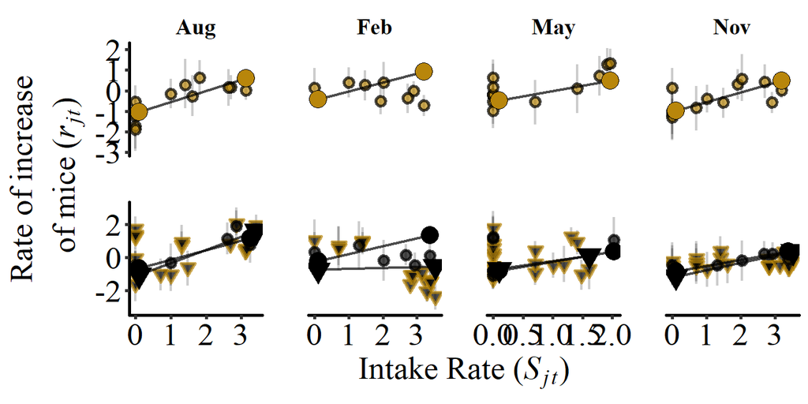

#### 5.2.1.1 February

```
 [1] 125.5429067 122.0759400   1.8775800  16.4246267  83.8898000
 [6] 137.7298933  66.4721267 135.1908467   0.5596733   9.6676600
[11] 145.6319600  68.5532733   0.6612267  83.2831467   5.7663800
[16]  23.4858000  13.6169000  39.2508533   0.7280600  20.3918133
[21]   5.7983333  22.9210000   0.4138533   6.3765333  17.2867467
[26]  98.0393533   0.7162933  25.0682000
```

This phase (Spring to Summer) has the weakest effect of `intake rate` on the population growth rates ($r_{jt}$).

[figure not shown]

#### 5.2.1.2 August

This phase (Autumn to winter) has the strongest effect of `intake rate` on the population growth rates ($r_{jt}$).

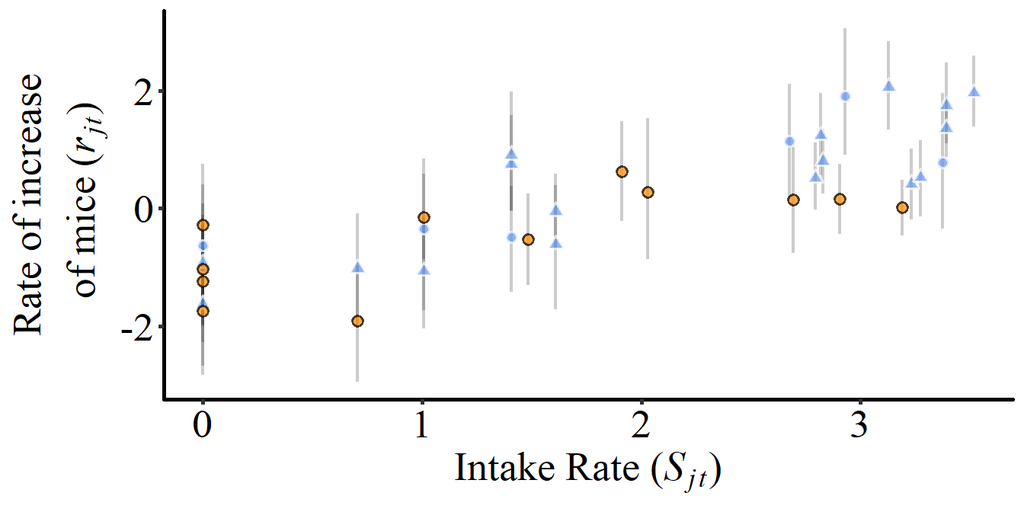

#### 5.2.1.3 November

[figure not shown]

### 5.2.2 Density

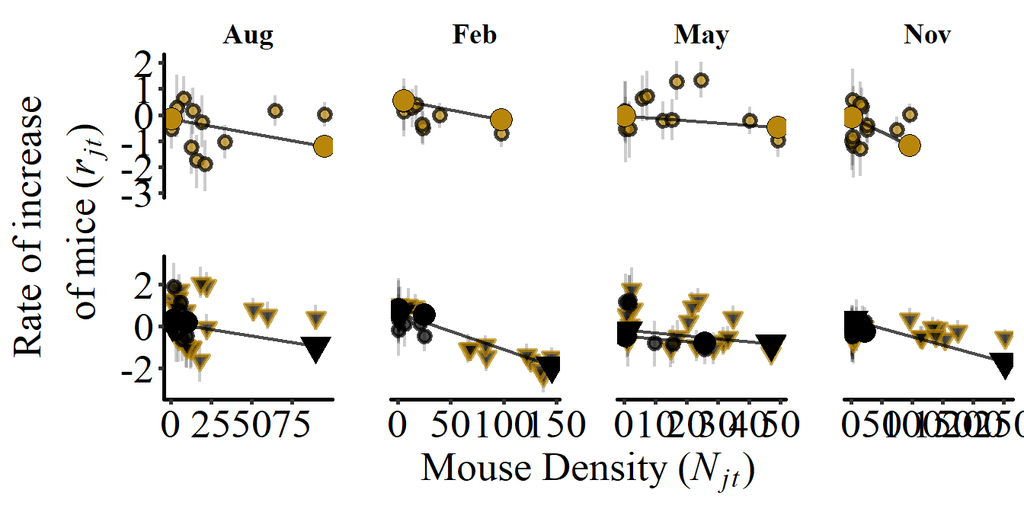

#### 5.2.2.1 February

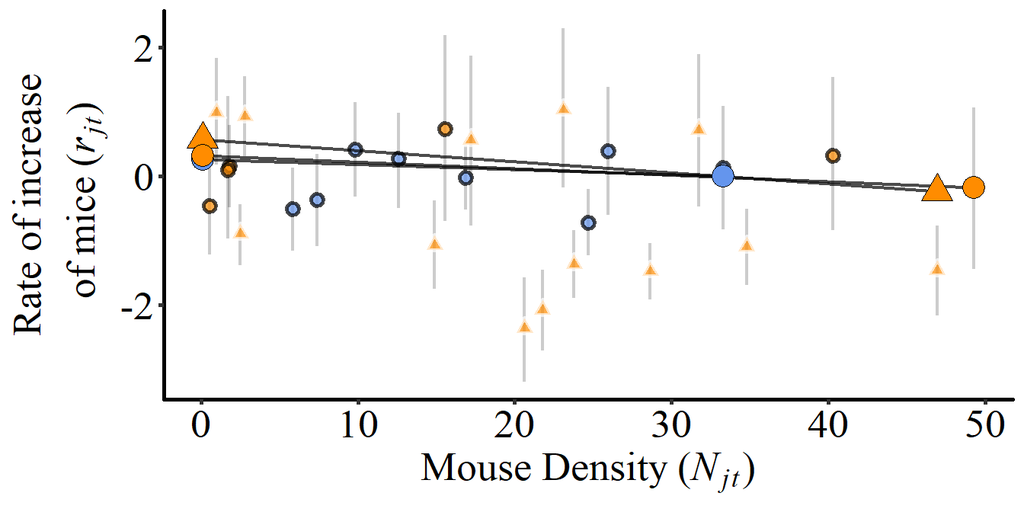

#### 5.2.2.2 May

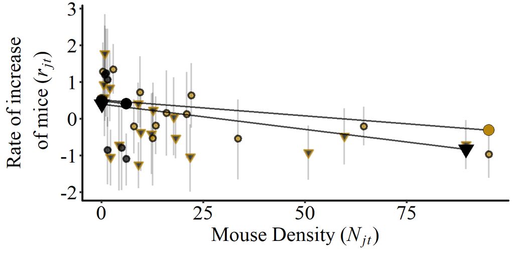

#### 5.2.2.3 August

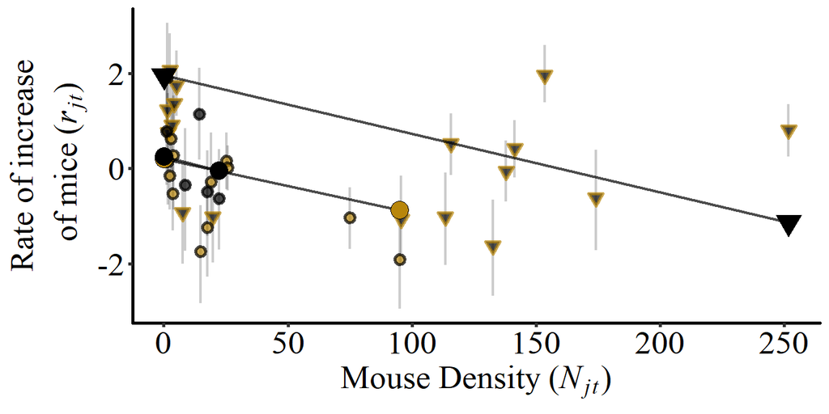

#### 5.2.2.4 November

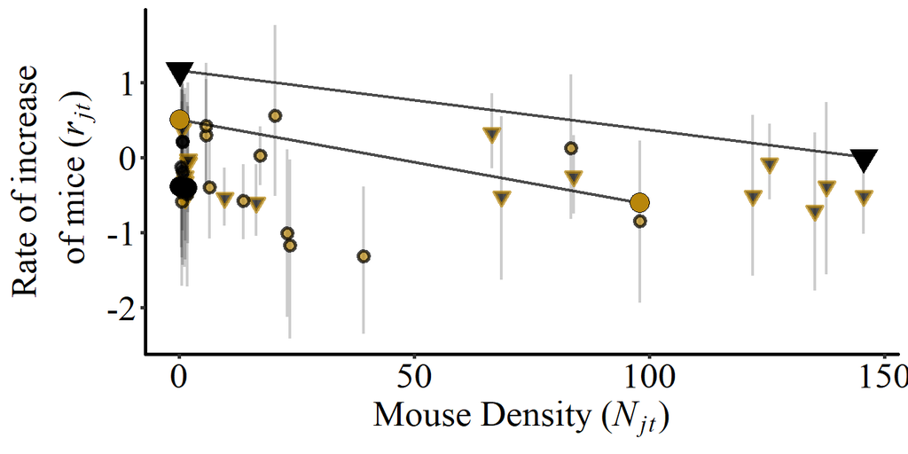

### 5.2.3 Rats

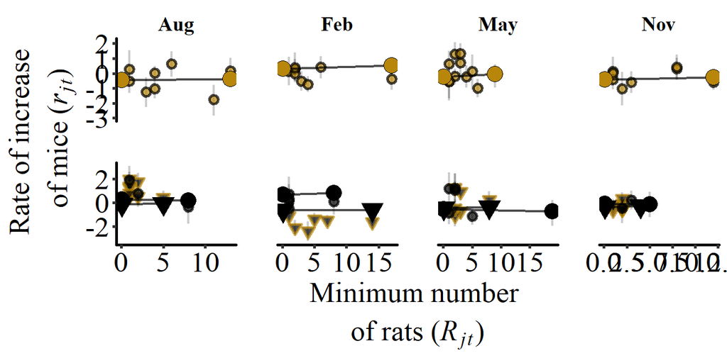

#### 5.2.3.1 February

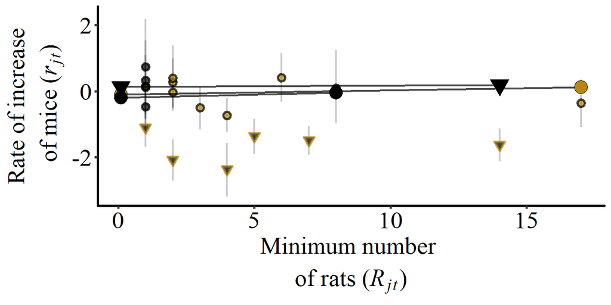

#### 5.2.3.2 May

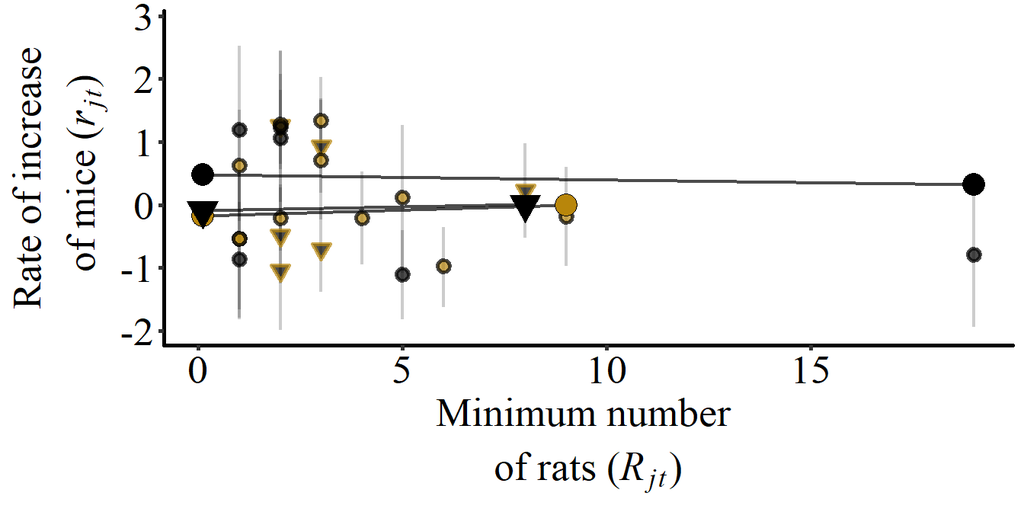

#### 5.2.3.3 August

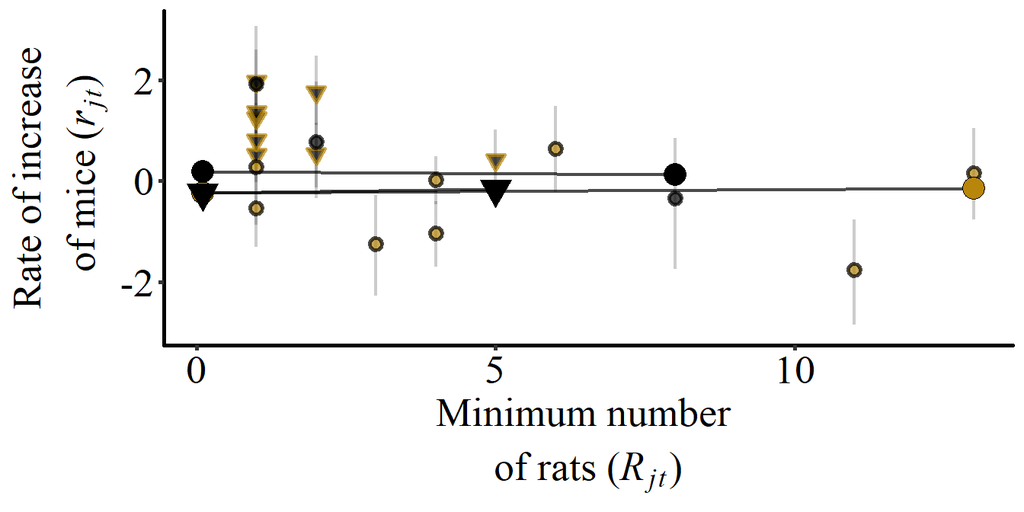

#### 5.2.3.4 November

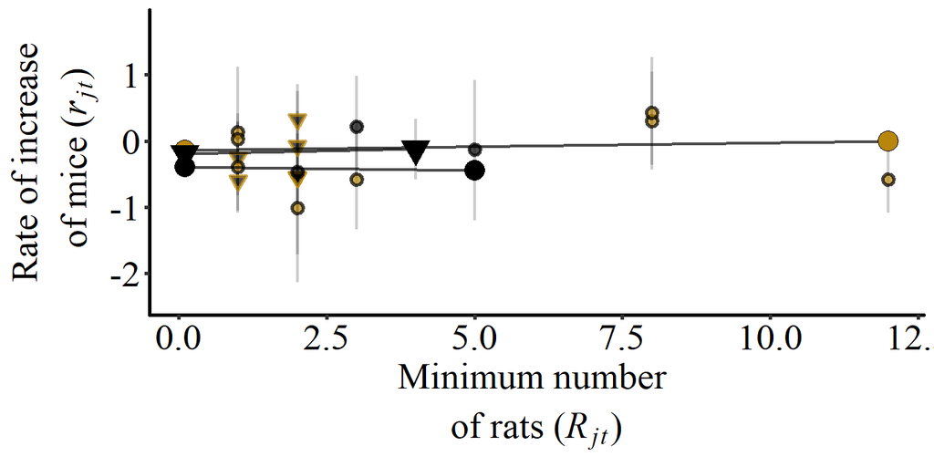

## 5.3 All model co-effiecents

### 5.3.1 v1

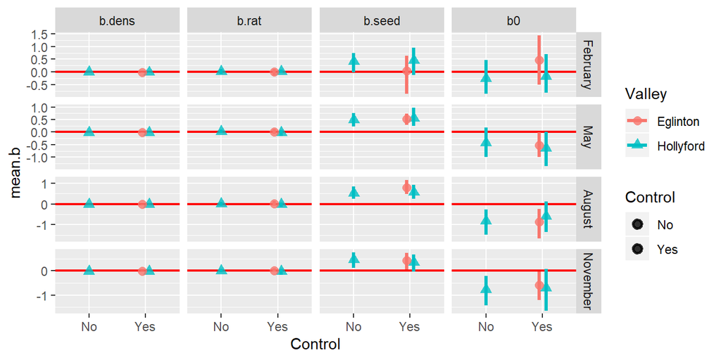

### 5.3.2 v2

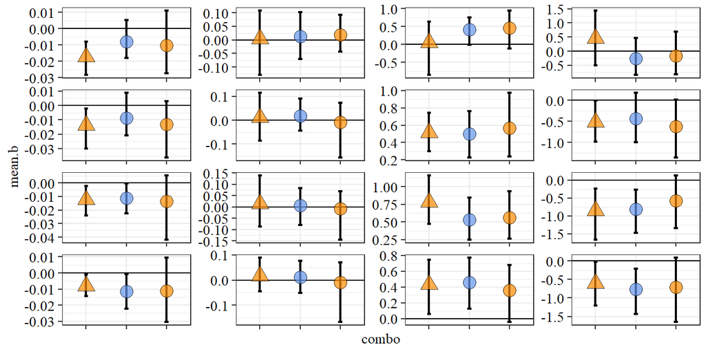

# 6 Results

## 6.1 Prediction C: Autumn and Winter trends

- Rate of increase between Autumn and Winter
- (May and August rate of change)
- May mice abundace, seed and rat data

### 6.1.1 August trend

This phase (Autumn to winter) has the strongest effect of `intake rate` on the population growth rates ($r_{jt}$).

### 6.1.2 Fitted plot

#### 6.1.2.1 v1

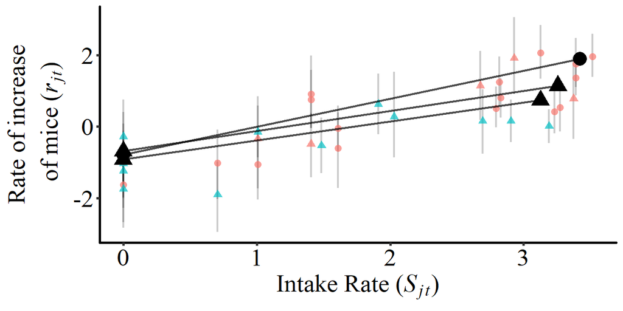

#### 6.1.2.2 v2

Data

#### 6.1.2.3 Another attempt

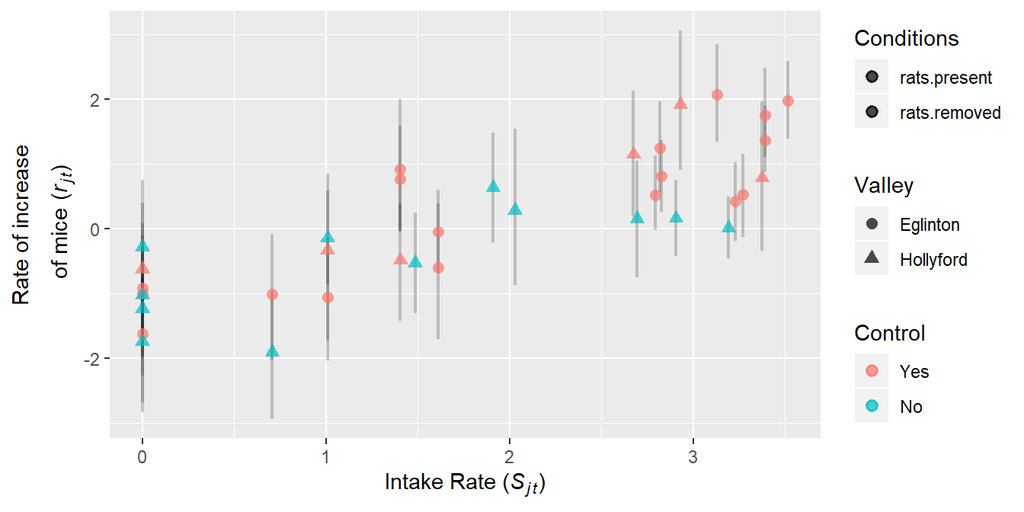

#### 6.1.2.4 v3

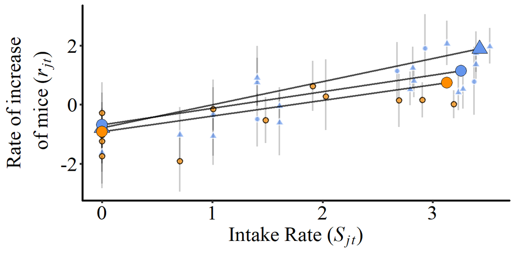

#### 6.1.2.5 v4

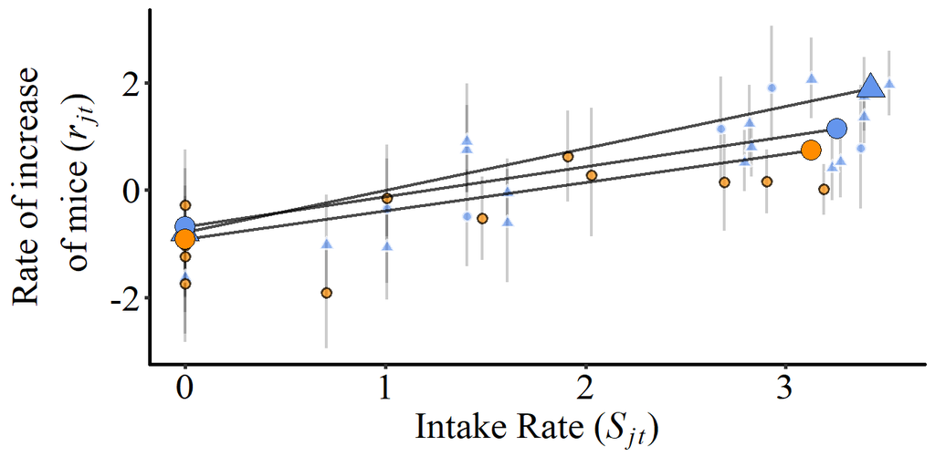

#### 6.1.2.6 New code

[figure not shown]

### 6.1.3 knitr figure

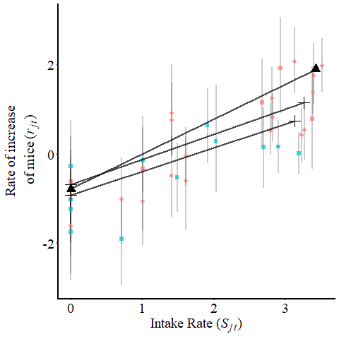

## 6.2 Prediction D

*Spring and Summer trends*

### 6.2.1 February

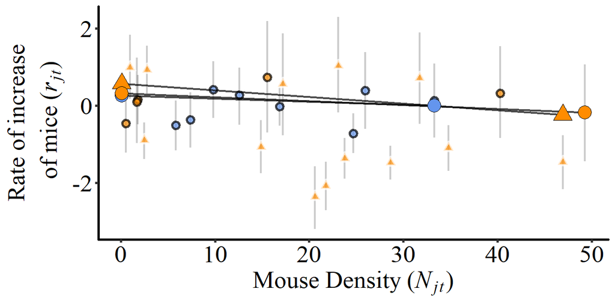

#### 6.2.1.1 old code

#### 6.2.1.2 New figure bandw

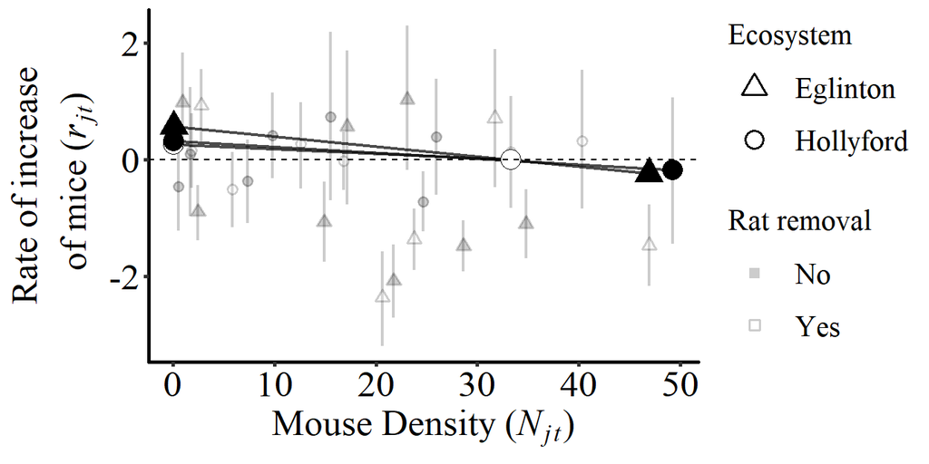

## 6.3 Prediction E

*Effect of rats*

### 6.3.1 Figure options

#### 6.3.1.1 old version

[figure not shown]

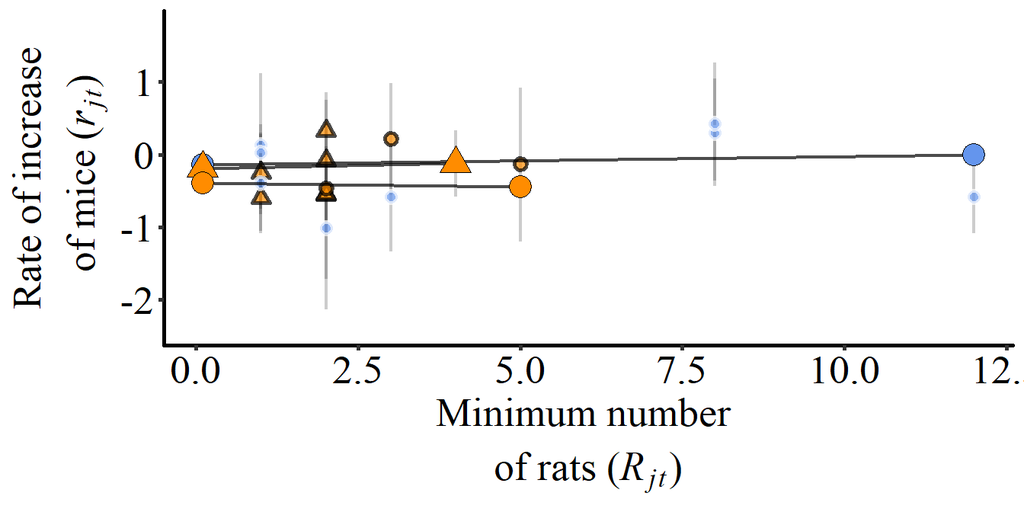

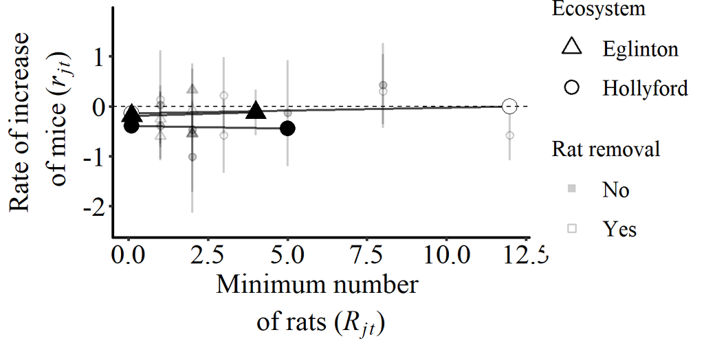

## 6.4 Output figures

# 7 Discussion

## 7.1 Saving

Must be `png`

# 8 Appendix

# 9 Final Words

We have finished a nice book.